# DecissionTree

185314135_DharuJiwoPambudi

29/4/2021

Dataset Diterima

Buat terlebih dahulu dataset tersebut, kemudian simpan data tersebut dalam bentuk cvs. Selanjutnyakan lakukan proses import data

```r
dataditerima <- read.csv("dataditerima.csv",sep=";")
str(dataditerima)
```

```
## 'data.frame':    11 obs. of  4 variables:
##  $ IPK      : chr  "Bagus" "Bagus" "Bagus" "Bagus" ...
##  $ Psikologi: chr  "Tinggi" "Sedang" "Sedang" "Rendah" ...
##  $ Wawancara: chr  "Baik" "Baik" "Buruk" " Buruk" ...
##  $ Diterima : chr  "Ya" "Ya" "Ya" "Tidak" ...
```

```r
dataditerima
```

```
##       IPK Psikologi Wawancara Diterima
## 1   Bagus    Tinggi      Baik       Ya
## 2   Bagus    Sedang      Baik       Ya
## 3   Bagus    Sedang     Buruk       Ya
## 4   Bagus    Rendah     Buruk    Tidak
## 5   Cukup    Tinggi      Baik       Ya
## 6   Cukup    Sedang      Baik       Ya
## 7   Cukup    Sedang     Buruk       Ya
## 8   Cukup    Rendah     Buruk    Tidak
## 9  Kurang    Tinggi      Baik       Ya
## 10 Kurang    Sedang     Buruk    Tidak
## 11 Kurang    Rendah      Baik       Ya
```

Step 2) Preprocessing Data

Beberapa tahapan preprosesing data yang perlu dilakukan :

```
Pastikan dataset telah memiliki kelas tujuan yang bertipe kategorikal (kasus klasifikasi).
Tidak ada data yang NA / bernilai null
Tentukan variabel-variabel yang akan digunakan untuk proses klasifikasi. Variabel yang tidak digunakan dapat dihilangkan.
Pada tahap ini perhatikan dataset yang digunakan. Tentukan class tujuan dan ubah tipe dari class.
Jika diperlukan lakukan proses suffle dataset (mengacak kembali dataset), terutama jika dataset yang digunakan akan digunakan untuk training dan testing.
```

Untuk kasus “Diterima” tahapan preprosesing yang dilakukan adalah membuat variabel Diterima menjadi bertipe factor karena merupakan atribut/variabel kategorikal sebagai kelas tujuan.

```r
dataditerima$Diterima <- factor(dataditerima$Diterima)
str(dataditerima)
```

```
## 'data.frame':    11 obs. of  4 variables:
##  $ IPK      : chr  "Bagus" "Bagus" "Bagus" "Bagus" ...
##  $ Psikologi: chr  "Tinggi" "Sedang" "Sedang" "Rendah" ...
##  $ Wawancara: chr  "Baik" "Baik" "Buruk" " Buruk" ...
##  $ Diterima : Factor w/ 2 levels "Tidak","Ya": 2 2 2 1 2 2 2 1 2 1 ...
```

Step 3) Membuat training data dan testing data

Sebelum membangun model dan mentraining model, perlu membagi dataset ke dalam 2 jenis dataset yaitu training dataset dan testing dataset. Beberapa cara untuk membagi data :

```
Bagi data secara random. Gunakan set.seed agar hasil yang selalu konsisten. Jika tidak menggunakan set.seed maka hasil akan selalu berubah.
```

```r
set.seed(12)
ind <- sample(2, nrow(dataditerima), replace=TRUE, prob=c(0.7, 0.3))
trainData <- dataditerima[ind==1,]
testData <- dataditerima[ind==2,]
trainData
```

```
##       IPK Psikologi Wawancara Diterima
## 1   Bagus    Tinggi      Baik       Ya
## 4   Bagus    Rendah     Buruk    Tidak
## 5   Cukup    Tinggi      Baik       Ya
## 6   Cukup    Sedang      Baik       Ya
## 7   Cukup    Sedang     Buruk       Ya
## 8   Cukup    Rendah     Buruk    Tidak
## 9  Kurang    Tinggi      Baik       Ya
## 10 Kurang    Sedang     Buruk    Tidak
## 11 Kurang    Rendah      Baik       Ya
```

```r
testData
```

```
##     IPK Psikologi Wawancara Diterima
## 2 Bagus    Sedang      Baik       Ya
## 3 Bagus    Sedang     Buruk       Ya
```

```
Bagi dataset sesuai urutan dataset.
```

Misalkan 70% data training dan 30% datatesting.

```r
n_row = nrow(dataditerima)
totalrow = 0.7*n_row
jumlahsampletraining <- 1 : totalrow
trainData <- dataditerima[jumlahsampletraining, ]
trainData
```

```
##     IPK Psikologi Wawancara Diterima
## 1 Bagus    Tinggi      Baik       Ya
## 2 Bagus    Sedang      Baik       Ya
## 3 Bagus    Sedang     Buruk       Ya
## 4 Bagus    Rendah     Buruk    Tidak
## 5 Cukup    Tinggi      Baik       Ya
## 6 Cukup    Sedang      Baik       Ya
## 7 Cukup    Sedang     Buruk       Ya
```

```r
testData <- dataditerima[-jumlahsampletraining, ]
testData
```

```
##       IPK Psikologi Wawancara Diterima
## 8   Cukup    Rendah     Buruk    Tidak
## 9  Kurang    Tinggi      Baik       Ya
## 10 Kurang    Sedang     Buruk    Tidak
## 11 Kurang    Rendah      Baik       Ya
```

untuk memudahkan agar membagi data secara konstan dapat diubah-ubah prosentasenya maka ubah script sebelumnya menjadi sebuah fungsi. Berikut fungsi nya :

```r
create_train_test <- function(data, size = 0.7, train = TRUE) {
    n_row = nrow(data)
    totalrow = size * n_row
    jumlahsampletraining <- 1: totalrow
    if (train == TRUE) {
        return (data[jumlahsampletraining, ])
    } else {
        return (data[-jumlahsampletraining, ])
    }
}
```

selanjutnya adalah memanggil fungsi create_train_test

```r
trainData <- create_train_test(dataditerima,0.7,train=TRUE)
trainData
```

```
##     IPK Psikologi Wawancara Diterima
## 1 Bagus    Tinggi      Baik       Ya
## 2 Bagus    Sedang      Baik       Ya
## 3 Bagus    Sedang     Buruk       Ya
## 4 Bagus    Rendah     Buruk    Tidak
## 5 Cukup    Tinggi      Baik       Ya
## 6 Cukup    Sedang      Baik       Ya
## 7 Cukup    Sedang     Buruk       Ya
```

```r
testData <- create_train_test(dataditerima,0.3,train=FALSE)
testData
```

```
##       IPK Psikologi Wawancara Diterima
## 4   Bagus    Rendah     Buruk    Tidak
## 5   Cukup    Tinggi      Baik       Ya
## 6   Cukup    Sedang      Baik       Ya
## 7   Cukup    Sedang     Buruk       Ya
## 8   Cukup    Rendah     Buruk    Tidak
## 9  Kurang    Tinggi      Baik       Ya
## 10 Kurang    Sedang     Buruk    Tidak
## 11 Kurang    Rendah      Baik       Ya
```

```r
#untuk mengecek hasil randomisasinya benar
prop.table(table(trainData$Diterima))
```

```
##
##     Tidak        Ya
## 0.1428571 0.8571429
```

```r
prop.table(table(testData$Diterima))
```

```
##
## Tidak    Ya
## 0.375 0.625
```

Ketika membagi data secara kontan, maka perlu diperhatikan dataset yang dimiliki Perhatikan untuk datatraining, IPK kurang tidak adalah datatraining. Atau misalnya jika kelas tujuannya diurutkan berdasarkan Diterima “Ya” terlebih dahulu, maka kemungkinan Diterima=“Tidak” tidak pernah akan ada dalam datatraining. Oleh karenanya untuk membagi data dengan cara ini, maka perlu terlebih dahulu melakukan dilakukan shuffle terhadap dataset yang miliki.

```r
shuffle_index = sample(1:nrow(dataditerima))
head(shuffle_index)
```

```
## [1] 11  2 10  1  6  4
```

```r
##sebelum dishuffle
dataditerima
```

```
##       IPK Psikologi Wawancara Diterima
## 1   Bagus    Tinggi      Baik       Ya
## 2   Bagus    Sedang      Baik       Ya
## 3   Bagus    Sedang     Buruk       Ya
## 4   Bagus    Rendah     Buruk    Tidak
## 5   Cukup    Tinggi      Baik       Ya
## 6   Cukup    Sedang      Baik       Ya
## 7   Cukup    Sedang     Buruk       Ya
## 8   Cukup    Rendah     Buruk    Tidak
## 9  Kurang    Tinggi      Baik       Ya
## 10 Kurang    Sedang     Buruk    Tidak
## 11 Kurang    Rendah      Baik       Ya
```

```r
dataditerima <- dataditerima[shuffle_index, ]
##setelah dishuffle
dataditerima
```

```
##       IPK Psikologi Wawancara Diterima
## 11 Kurang    Rendah      Baik       Ya
## 2   Bagus    Sedang      Baik       Ya
## 10 Kurang    Sedang     Buruk    Tidak
## 1   Bagus    Tinggi      Baik       Ya
## 6   Cukup    Sedang      Baik       Ya
## 4   Bagus    Rendah     Buruk    Tidak
## 9  Kurang    Tinggi      Baik       Ya
## 5   Cukup    Tinggi      Baik       Ya
## 3   Bagus    Sedang     Buruk       Ya
## 7   Cukup    Sedang     Buruk       Ya
## 8   Cukup    Rendah     Buruk    Tidak
```

```r
trainData <- create_train_test(dataditerima,0.7,train=TRUE)
trainData
```

```
##       IPK Psikologi Wawancara Diterima
## 11 Kurang    Rendah      Baik       Ya
## 2   Bagus    Sedang      Baik       Ya
## 10 Kurang    Sedang     Buruk    Tidak
## 1   Bagus    Tinggi      Baik       Ya
## 6   Cukup    Sedang      Baik       Ya
## 4   Bagus    Rendah     Buruk    Tidak
## 9  Kurang    Tinggi      Baik       Ya
```

```r
testData <- create_train_test(dataditerima,0.3,train=FALSE)
testData
```

```
##      IPK Psikologi Wawancara Diterima
## 1  Bagus    Tinggi      Baik       Ya
## 6  Cukup    Sedang      Baik       Ya
## 4  Bagus    Rendah     Buruk    Tidak
## 9 Kurang    Tinggi      Baik       Ya
## 5  Cukup    Tinggi      Baik       Ya
## 3  Bagus    Sedang     Buruk       Ya
## 7  Cukup    Sedang     Buruk       Ya
## 8  Cukup    Rendah     Buruk    Tidak
```

```r
#untuk mengecek hasil randomisasinya benar
prop.table(table(trainData$Diterima))
```

```
##
##     Tidak        Ya
## 0.2857143 0.7142857
```

```r
prop.table(table(testData$Diterima))
```

```
##
## Tidak    Ya
##  0.25  0.75
```

```r
testData <- read.csv("dataditerimatesting.csv",sep=";")
testData$Diterima <- factor(testData$Diterima)
str(testData)
```

```
## 'data.frame':    3 obs. of  4 variables:
##  $ IPK      : chr  "Kurang" "Bagus" "Bagus"
##  $ Psikologi: chr  "Sedang" "Rendah" "Rendah"
##  $ Wawancara: chr  "Baik" "Buruk" "Baik"
##  $ Diterima : Factor w/ 2 levels "Tidak","Ya": 2 2 1
```

```r
## data training dari dataditerima
trainData <- read.csv("dataditerima.csv",sep=";")
trainData$Diterima <- factor(trainData$Diterima)
str(trainData)
```

```
## 'data.frame':    11 obs. of  4 variables:
##  $ IPK      : chr  "Bagus" "Bagus" "Bagus" "Bagus" ...
##  $ Psikologi: chr  "Tinggi" "Sedang" "Sedang" "Rendah" ...
##  $ Wawancara: chr  "Baik" "Baik" "Buruk" " Buruk" ...
##  $ Diterima : Factor w/ 2 levels "Tidak","Ya": 2 2 2 1 2 2 2 1 2 1 ...
```

Step 4) : Membangun model decision Tree

untuk membangun model, gunakan fungsi rpart dari library rpart. Sintaknya adalah : rpart(formula, data= , method = ’’), arguments :

```
formula = variabel-variabel yang akan diprediksi
data : data yang digunakan untuk membangun model
method : “class” untuk classification tree, “anova” untuk regression tree
```

merupakan minimal argument yang dapat digunakan untuk membangun model

dapat ditambahkan argument untuk meningkat performa dari decision tree, yaitu menggunakan fungsi rpart.control()

rpart.control(minsplit = 20, minbucket = round(minsplit/3), maxdepth = 30)

Arguments:

-minsplit: Set the minimum number of observations in the node before the algorithm perform a split -minbucket: Set the minimum number of observations in the final note i.e. the leaf -maxdepth: Set the maximum depth of any node of the final tree. The root node is treated a depth 0

sehingga jika ingin dilengkapi maka fungsi rpart menjadi : rpart(formula, data= , method = ’’,control=rpart.control()

Secara default, fungsi rpart() menggunakan the Gini impurity measure untuk membagi atributnya. Makin tinggi Gini coefficient, makin berbeda dataset dalam suatu atribut

```r
library(rpart)
library(rpart.plot)
##default:
fit <- rpart(Diterima~.,data=trainData,method="class")

## tuning:
fit <- rpart(Diterima~.,data=trainData,method="class",control=rpart.control(minsplit=2))
##atau
fit <- rpart(Diterima~IPK+Wawancara+Psikologi,data=trainData,method="class",control=rpart.control(minsplit=2))

##atau
formula <- Diterima~Wawancara+IPK+Psikologi
fit <- rpart(formula,data=trainData,method="class")
fit <- rpart(formula,data=trainData,control=rpart.control(minsplit=2))
fit
```

```
## n= 11
##
## node), split, n, loss, yval, (yprob)
##       * denotes terminal node
##
##  1) root 11 3 Ya (0.2727273 0.7272727)
##    2) Wawancara= Buruk,Buruk 5 2 Tidak (0.6000000 0.4000000)
##      4) Psikologi=Rendah 2 0 Tidak (1.0000000 0.0000000) *
##      5) Psikologi=Sedang 3 1 Ya (0.3333333 0.6666667)
##       10) IPK=Kurang 1 0 Tidak (1.0000000 0.0000000) *
##       11) IPK=Bagus,Cukup 2 0 Ya (0.0000000 1.0000000) *
##    3) Wawancara=Baik 6 0 Ya (0.0000000 1.0000000) *
```

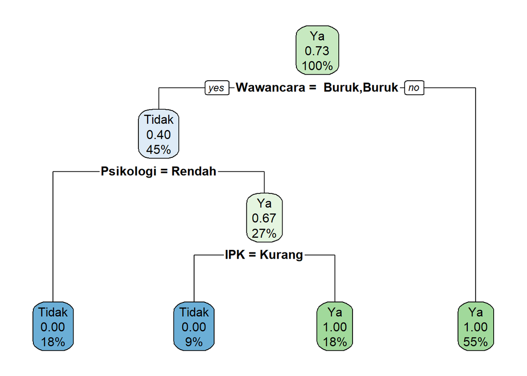

```r
## menggambarkan plot
rpart.plot(fit,extra=106)
```

Penjelasan :

```
rpart() : Fungsi untuk membangun model. Argument:
    Diterima ~ . : Formula dari Decision Tree. Variabel Diterima terhadap keseluruhan atribut yang lainnya (.). Jika variabel yang hendak dibangun model tidak keseluruhan, maka harus disebutkan satu persatu : Diterima ~ IPK+Wawancara+Psikologi.
    data = trainData : merupakan dataset yang akan ditraining
    method = “class”
    control=rpart.control(minsplit=2) : minsplit = 2

rpart.plot() untuk membuat plot. Argumen extra = 106 untuk binary, 104 = ditampilkan lebih dari 2 level. 100 = untuk lainnya. “auto” –> nilai Default
```

Beberapa cara untuk menggambarkan plot hasil decision tree :

```
Menggunakan rpart.plot()
Menggunakan plot ()
Menggunakan library(rattle),library(rpart.plot) dan library(RColorBrewer)
```

Menggunakan rpart.plot()

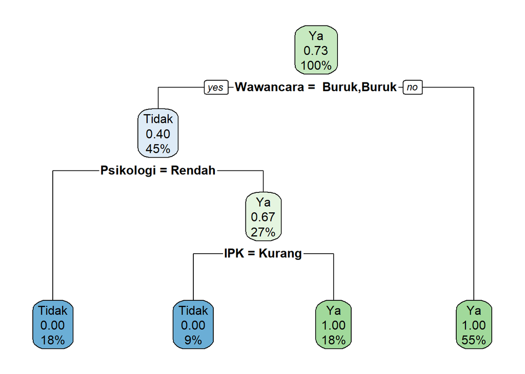

```r
## Menggambarkan plot dengan rpart.plot()
library(rpart.plot)
rpart.plot(fit,extra=106)
```

Menggunakan plot()

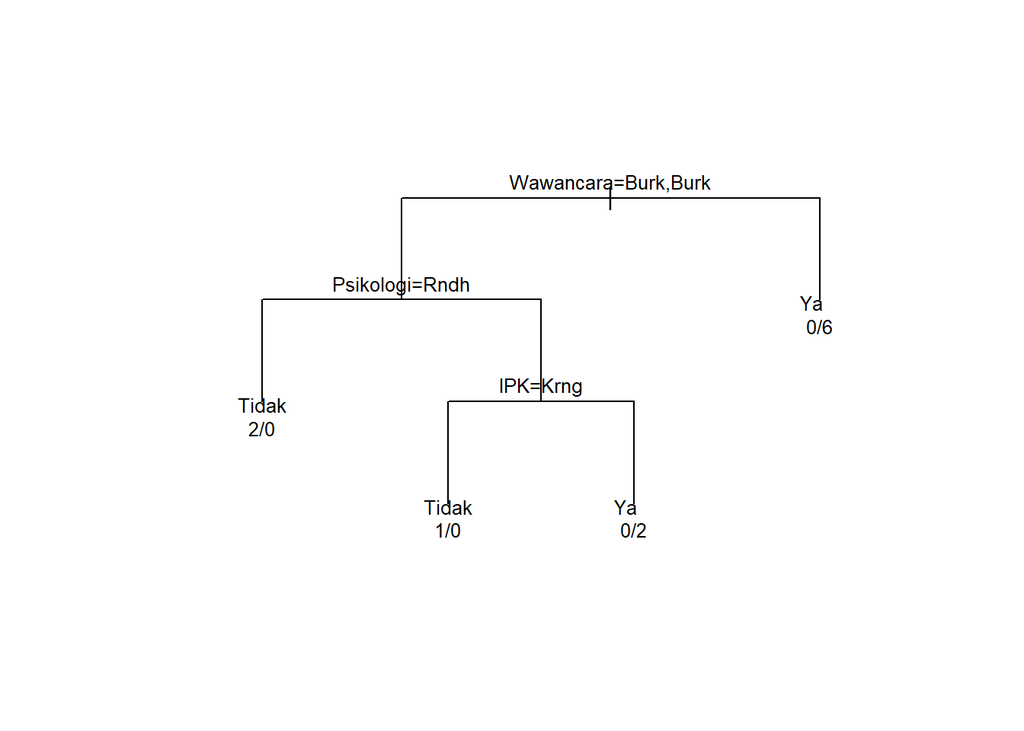

```r
## Menggambarkan plot dengan plot()


plot(fit,margin=0.2)
text(fit, use.n=TRUE,pretty=TRUE,cex=0.8)
```

Menggunakan fungsi fancyRpartPlot() dari library rattle()

```r
library(rattle)
```

[figure not shown]

```r
fancyRpartPlot(fit)
```

### Step 5) : Membuat prediksi

Untuk membuat prediksi, menggunakan fungsi predict(). Secara default syantax untuk melakukan prediksi dari R decision tree adalah :

predict(fitted_model, df, type=class) arguments: - fitted_model : Model yang telah dibangun - df : data yang akan diprediksi - type : Jenis prediksi : - ‘class’ : untuk klasifikasi - ‘prob’ : untuk menghitung probabilistik setiap kelas - ‘vector’ : untuk memprediksi mean rerponse pada setiap node

Akan dilakukan prediksi terhadap data testing. Data testing yang akan digunakan adalah dataditerima_testing (variabel : testData). Melihat hasil prediksi dari datatesting mana yang diterima dan yang tidak.

```r
prediksi <- predict(fit,newdata=testData,type="class")
prediksi
```

```
##     1     2     3
##    Ya Tidak    Ya
## Levels: Tidak Ya
```

Hasil prediksi adalah

```
Data pertama : Ya
Data kedua : Tidak
Data ketiga : Ya.
```

Menghitung total yang diterima dan yang tidak diterima, dapat menggunakan table

```r
table_mat <- table(testData$Diterima,prediksi)

table_mat
```

```
##        prediksi
##         Tidak Ya
##   Tidak     0  1
##   Ya        1  1
```

Model dapat memprediksi data yang diterima adalah 1, sementara yang lain tidak tepat hasil prediksinya. Step 6) : Evaluasi model / mengukur performance

Evaluasi model, dapat dilakukan dengan mengukur akurasinya yaitu menggunakan confusion matrix

Akurasi diperoleh dari jumlah hasil diagonal dari confussion matrix dibagi dengan keseluruhan data. table_mat merupakan table confussion matrix.

```r
akurasi <- sum(diag(table_mat))/sum(table_mat)
print(paste("Hasil akurasinya adalah  : ", akurasi))
```

```
## [1] "Hasil akurasinya adalah  :  0.333333333333333"
```

Atau dapat menggunakan fungsi confusionMatrix dari library(caret)

```r
library(caret)
confusionMatrix(table(testData$Diterima,prediksi))
```

```
## Confusion Matrix and Statistics
##
##        prediksi
##         Tidak Ya
##   Tidak     0  1
##   Ya        1  1
##
##                Accuracy : 0.3333
##                  95% CI : (0.0084, 0.9057)
##     No Information Rate : 0.6667
##     P-Value [Acc > NIR] : 0.963
##
##                   Kappa : -0.5
##
##  Mcnemar's Test P-Value : 1.000
##
##             Sensitivity : 0.0000
##             Specificity : 0.5000
##          Pos Pred Value : 0.0000
##          Neg Pred Value : 0.5000
##              Prevalence : 0.3333
##          Detection Rate : 0.0000
##    Detection Prevalence : 0.3333
##       Balanced Accuracy : 0.2500
##
##        'Positive' Class : Tidak
##
```

```r
confusionMatrix(table(testData$Diterima,prediksi))
```

```
## Confusion Matrix and Statistics
##
##        prediksi
##         Tidak Ya
##   Tidak     0  1
##   Ya        1  1
##
##                Accuracy : 0.3333
##                  95% CI : (0.0084, 0.9057)
##     No Information Rate : 0.6667
##     P-Value [Acc > NIR] : 0.963
##
##                   Kappa : -0.5
##
##  Mcnemar's Test P-Value : 1.000
##
##             Sensitivity : 0.0000
##             Specificity : 0.5000
##          Pos Pred Value : 0.0000
##          Neg Pred Value : 0.5000
##              Prevalence : 0.3333
##          Detection Rate : 0.0000
##    Detection Prevalence : 0.3333
##       Balanced Accuracy : 0.2500
##
##        'Positive' Class : Tidak
##
```

Step 7) : Tuning parameter

Untuk dapat meningkatkan akurasi, maka yang perlu dilakukan adalah melakukan tuning parameter control,yaitu:

```
minsplit,
minbucket,
maxdept dan
cp(complexity parameter) yaitu ukuran kompleksitas dalam membangun tree. Jika cost untuk menambahkan variabel ke dalam tree melebih dari curent tree melebih nilai cp maka proses membangun tree tidak dilanjutkan.
```

Untuk melihat cp dapat dilakukan dengan menggunakan

```r
 print(fit$cptable)
```

```
##          CP nsplit rel error xerror      xstd
## 1 0.3333333      0         1      1 0.4923660
## 2 0.0100000      3         0      2 0.5504819
```

Untuk melakukan tuning paramater, dilakukan dengan mensettup rpart.control

```r
control <- rpart.control(minsplit=2,minbucket=round(4/3),maxdept=3,cp=0)

    control <- rpart.control(minsplit=2,minbucket=round(4/3),maxdept=3,cp=0)
    tune_fit <- rpart(Diterima~.,data=trainData,method='class',control=control)
    tune_fit
```

```
## n= 11
##
## node), split, n, loss, yval, (yprob)
##       * denotes terminal node
##
##  1) root 11 3 Ya (0.2727273 0.7272727)
##    2) Wawancara= Buruk,Buruk 5 2 Tidak (0.6000000 0.4000000)
##      4) Psikologi=Rendah 2 0 Tidak (1.0000000 0.0000000) *
##      5) Psikologi=Sedang 3 1 Ya (0.3333333 0.6666667)
##       10) IPK=Kurang 1 0 Tidak (1.0000000 0.0000000) *
##       11) IPK=Bagus,Cukup 2 0 Ya (0.0000000 1.0000000) *
##    3) Wawancara=Baik 6 0 Ya (0.0000000 1.0000000) *
```

```r
    prediksi <- predict(fit,newdata=testData,type="class")
    prediksi
```

```
##     1     2     3
##    Ya Tidak    Ya
## Levels: Tidak Ya
```

```r
    confusionMatrix(table(testData$Diterima,prediksi))
```

```
## Confusion Matrix and Statistics
##
##        prediksi
##         Tidak Ya
##   Tidak     0  1
##   Ya        1  1
##
##                Accuracy : 0.3333
##                  95% CI : (0.0084, 0.9057)
##     No Information Rate : 0.6667
##     P-Value [Acc > NIR] : 0.963
##
##                   Kappa : -0.5
##
##  Mcnemar's Test P-Value : 1.000
##
##             Sensitivity : 0.0000
##             Specificity : 0.5000
##          Pos Pred Value : 0.0000
##          Neg Pred Value : 0.5000
##              Prevalence : 0.3333
##          Detection Rate : 0.0000
##    Detection Prevalence : 0.3333
##       Balanced Accuracy : 0.2500
##
##        'Positive' Class : Tidak
##
```